# Assignment 7: Visualization - Some aspects of ggplot2

*How to do it?*:

- Open the Rmarkdown file of this assignment (link) in Rstudio.
- Right under each **question**, insert a code chunk (you can use the hotkey `Ctrl + Alt + I` to add a code chunk) and code the solution for the question.
- `Knit` the rmarkdown file (hotkey: `Ctrl + Alt + K`) to export an html.
- Publish the html file to your Githiub Page.

*Submission*: Submit the link on Github of the assignment to Canvas

Use the data of your own. Produce the following types of plots and comment on each plot. Plots should be meaningful. If you use the data we used in class, make sure the plots are not the same as the ones in the slides. All plots should have title, caption, appropriate labels on x and y-axis.

```r
library(tidyverse)
library(knitr)
library(ggplot2)
df <- read_csv('https://bryantstats.github.io/math421/data/titanic.csv')
```

1. Make a plot using `facet_wrap` by one categorical variable (`facet_wrap(~variable1)`)

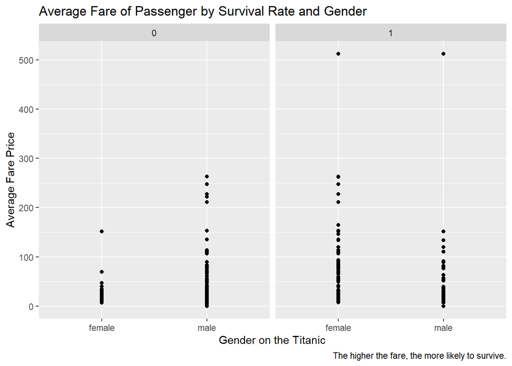

```r
df %>% ggplot()+
  geom_point(mapping=aes(x=Sex, y=Fare))+
  facet_wrap(~Survived) +
  labs(x='Gender on the Titanic',
       y = 'Average Fare Price',
       title = 'Average Fare of Passenger by Survival Rate and Gender',
       caption = 'The higher the fare, the more likely to survive.')
```

This plot splits the people who survived and the people who did not survive, shows them side by side, and in each one it shows how much their ticket cost and what their gender is.

2. Make a plot using `facet_wrap` by two categorical variables (`facet_wrap(~variable1+variable2)`)

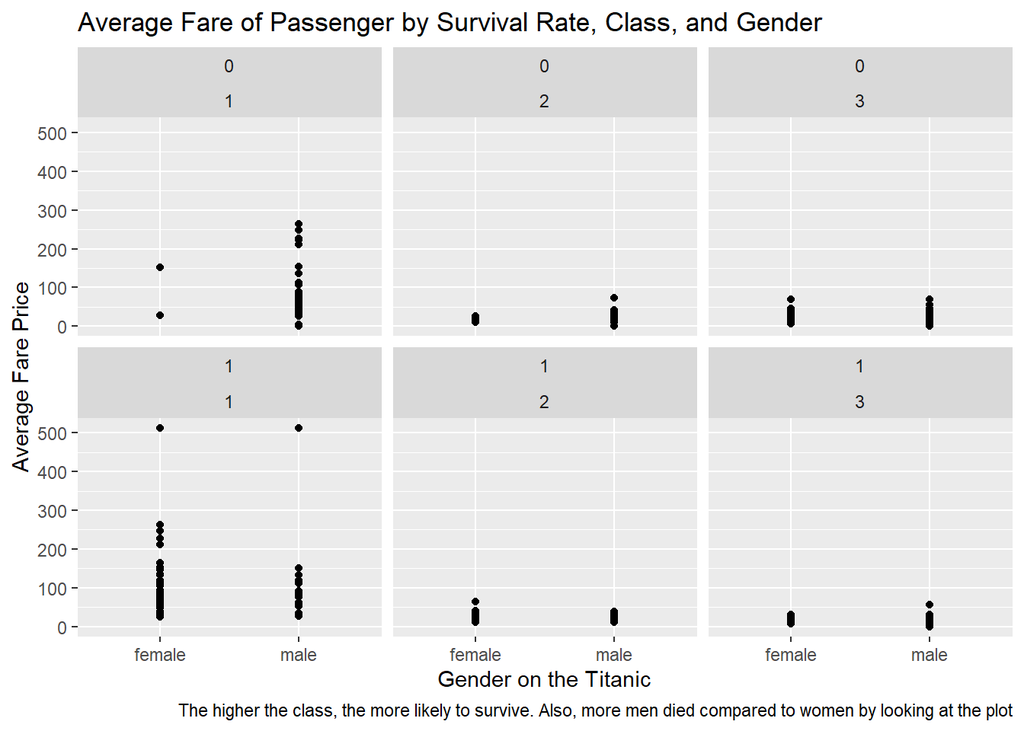

```r
df %>% ggplot()+
  geom_point(mapping=aes(x=Sex, y=Fare))+
  facet_wrap(~Survived + Pclass) +
  labs(x='Gender on the Titanic',
       y = 'Average Fare Price',
       title = 'Average Fare of Passenger by Survival Rate, Class, and Gender',
       caption = 'The higher the class, the more likely to survive. Also, more men died compared to women by looking at the plot')
```

This plot splits the people who survived and the people who did not survive,and splits them by class as well. It shows this side by side, and in each one it shows how much their ticket cost and what their gender is.

3. Make a plot using `position ='dodge'`.

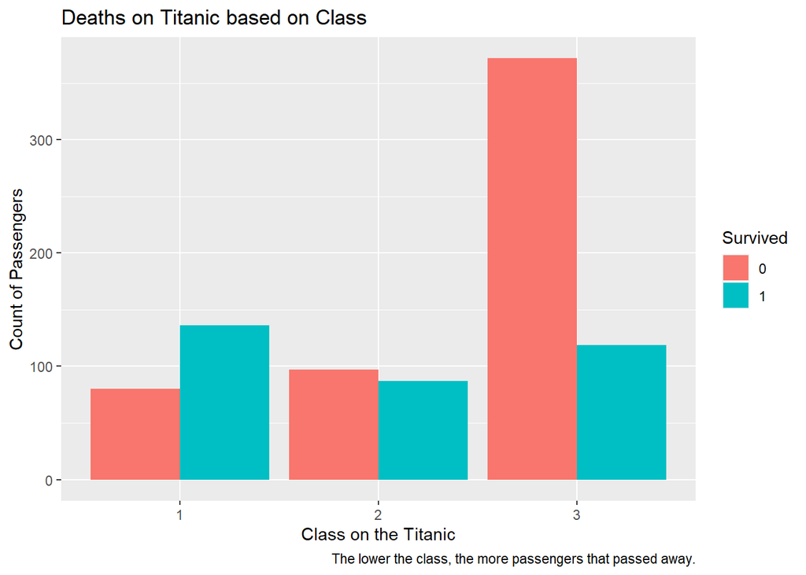

```r
df$Pclass = factor(df$Pclass)
df$Survived = factor(df$Survived)
df %>% ggplot()+
  geom_bar(mapping=aes(x=Pclass, fill=Survived),
           position = 'dodge') +
  labs(x='Class on the Titanic',
       y = 'Count of Passengers',
       title = 'Deaths on Titanic based on Class',
       caption = 'The lower the class, the more passengers that passed away.')
```

This plot shows how many people died on the titanic based on their class.

4. Make a plot using `position ='fill'`.

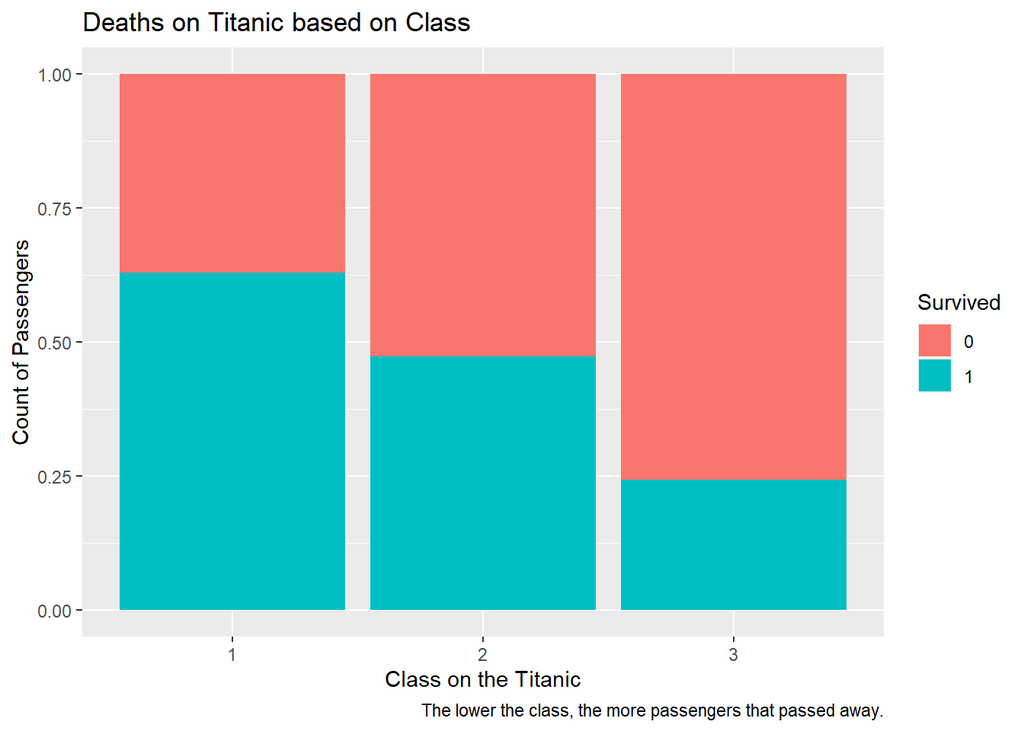

```r
df$Pclass = factor(df$Pclass)
df$Survived = factor(df$Survived)
df %>% ggplot()+
  geom_bar(mapping=aes(x=Pclass, fill=Survived),
           position = 'fill') +
  labs(x='Class on the Titanic',
       y = 'Count of Passengers',
       title = 'Deaths on Titanic based on Class',
       caption = 'The lower the class, the more passengers that passed away.')
```

This plot shows how many people died on the titanic based on their class. I believe it is easier to see on this graph compared to the previous one that the lower the class the more passengers that passed away.

5. Make a plot using `geom_col`.

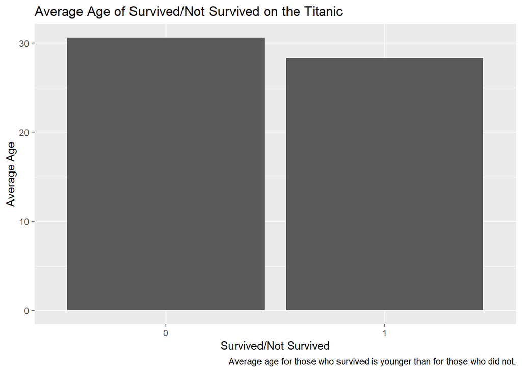

```r
df %>% group_by(Survived) %>%
  summarise(average_age=mean(Age, na.rm=TRUE)) %>%
  ggplot()+
  geom_col(mapping=aes(x=Survived, y=average_age))+
  labs(x='Survived/Not Survived',
       y = 'Average Age',
       title = 'Average Age of Survived/Not Survived on the Titanic',
       caption = 'Average age for those who survived is younger than for those who did not.')
```

This plot shows the average age of passengers who died and passengers who lived that were on the titanic.

6. Change the theme of one of your plots. Problem 4 plot

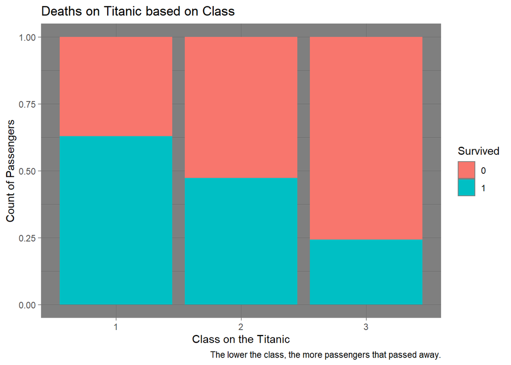

```r
df$Pclass = factor(df$Pclass)
df$Survived = factor(df$Survived)
df %>% ggplot()+
  geom_bar(mapping=aes(x=Pclass, fill=Survived),
           position = 'fill') +
  labs(x='Class on the Titanic',
       y = 'Count of Passengers',
       title = 'Deaths on Titanic based on Class',
       caption = 'The lower the class, the more passengers that passed away.')+
  theme_dark()
```

This is the same plot used in problem 4; however, I used the dark theme with it instead of the regular theme.